# Sesión 6

[figure not shown]

Profesor: [Dr. José Manuel MAGALLANES REYES, Ph.D.](http://www.pucp.edu.pe/profesor/jose-manuel-magallanes/)

- Profesor del Departamento de Ciencias Sociales, Sección de Ciencia Política y Gobierno.
- [Oficina 105](https://goo.gl/maps/xuGeG6o9di1i1y5m6) - Edificio CISEPA / ECONOMIA / CCSS
- Telefono: (51) 1 - 6262000 anexo 4302
- Correo Electrónico: jmagallanes@pucp.edu.pe

## Análisis de Variables Latentes

[figure not shown]

Muchas veces queremos saber si algun conjunto de variables representa algun *concepto*, al cual se le denomina técnicamente *variable latente*. Las técnicas son variadas, pero aquí aplicaremos análisis factorial, el exploratorio y el confirmatorio para tratar de *reducir* varias variables en otra u otras más simples.

# 1 Preprocesamiento:

Para esta sesión trabajaremos con la data de:

- [Índice de Desarrollo Humano](https://es.wikipedia.org/wiki/Anexo:Pa%C3%ADses_por_%C3%ADndice_de_desarrollo_humano)
- [Índice de Democracia](https://es.wikipedia.org/wiki/%C3%8Dndice_de_democracia)

## 1.1 Carga de datos

Para esta etapa vamos a proceder a *scrapear* las dos páginas web, con la ayuda de la biblioteca *htmltab*. La descarga utilizará el *xpath* de la tabla de interés.

```r
rm(list = ls())

library(htmltab)

# links
WhereIDH=list(page="https://es.wikipedia.org/wiki/Anexo:Pa%C3%ADses_por_%C3%ADndice_de_desarrollo_humano",
              xpath='//*[@id="mw-content-text"]/div[1]/table[4]/tbody')
WhereDEMO=list(page="https://es.wikipedia.org/wiki/%C3%8Dndice_de_democracia",
               xpath='//*[@id="mw-content-text"]/div[1]/div[4]/div/table/tbody')

#carga
idh  = htmltab(doc = WhereIDH$page,
               which  = WhereIDH$xpath,
               encoding = "UTF-8")
demo  = htmltab(doc = WhereDEMO$page,
               which  = WhereDEMO$xpath,
               encoding = "UTF-8")
```

## 1.2 Limpieza

Por lo general, la data scrapeada presenta diversas ‘impurezas’. Veámos qué se necesita ‘limpiar’.

- **Nombres de columnas**: Hay que tratar de tener nombres simples, sin espacios ni caracteres especiales. Si se desea mantener nombres descriptivos, puede hacerse uso de guiones bajos (underscores) o formato *CamelCase*.

Los nombres de la data *idh* son muy largos, con caracteres especiales, en español, y muchos espacios en blancos.

```r
names(idh)
```

```
## [1] "País >> IDH Muy Alto >> IDH Alto >> IDH Medio >> IDH Bajo"
## [2] "Componentes para Indice de Desarrollo Humano >> Esperanza de Vida (85 años) >> IDH Muy Alto >> IDH Alto >> IDH Medio >> IDH Bajo"
## [3] "Componentes para Indice de Desarrollo Humano >> Años Esperados de Escolaridad ( 18 años) >> IDH Muy Alto >> IDH Alto >> IDH Medio >> IDH Bajo"
## [4] "Componentes para Indice de Desarrollo Humano >> Años Promedio de Escolaridad (15 años) >> IDH Muy Alto >> IDH Alto >> IDH Medio >> IDH Bajo"
## [5] "Componentes para Indice de Desarrollo Humano >> PIB per capita PPP (2017) (75,000) >> IDH Muy Alto >> IDH Alto >> IDH Medio >> IDH Bajo"
```

Los nombres de la data *demo* no son muy largos, con caracteres en español, y muchos espacios en blancos.

```r
names(demo)
```

```
## [1] "Puesto"                        "País"
## [3] "Puntuación"                    "Proceso electoraly pluralismo"
## [5] "Funcionamientodel gobierno"    "Participaciónpolítica"
## [7] "Culturapolítica"               "Derechosciviles"
## [9] "Categoría"
```

Por lo visto, hay que cambiar los nombres en ambas tablas.

```r
# en IDH
## cambio total
newNames=c('Pais','EsperanzaVida','EscolaridadDuracion','EscolaridadPromedio','PBI')
names(idh)=newNames

# en DEMO
## Capitalizar
library(stringr)
names(demo)=str_to_title(names(demo))

## sin tildes ni ñs.
library(stringi)
names(demo)=stri_trans_general(str = names(demo),
                               id = "Latin-ASCII")
## sin espacios
names(demo)=gsub(" ","",names(demo))
```

- **Valores en las celdas**: Por lo general, hay que asegurarse que no haya espacios en blanco ni al inicio ni al final de cada valor en una celda.

```r
idh[,]=lapply(idh[,], trimws,whitespace = "[\\h\\v]")

demo[,]=lapply(demo[,], trimws,whitespace = "[\\h\\v]")
```

## 1.3 Formateo

Hablamos de formateo cuando buscamos que los valores de cada celda estén el correcto tipo de dato. Para ello debemos primero ver qué tipo ha sido asignado por R.

```r
str(idh)
```

```
## 'data.frame':    191 obs. of  5 variables:
##  $ Pais               : chr  "Suiza" "Noruega" "Islandia" "Hong Kong" ...
##  $ EsperanzaVida      : chr  "84.0" "83.2" "82.7" "85.5" ...
##  $ EscolaridadDuracion: chr  "16.5" "18.2" "19.2" "17.3" ...
##  $ EscolaridadPromedio: chr  "13.9" "13.0" "13.8" "12.2" ...
##  $ PBI                : chr  "66,933" "64,660" "55,782" "62,607" ...
```

```r
str(demo)
```

```
## 'data.frame':    167 obs. of  9 variables:
##  $ Puesto                     : chr  "1" "2" "3" "4" ...
##  $ Pais                       : chr  "Noruega" "Nueva Zelanda" "Finlandia" "Suecia" ...
##  $ Puntuacion                 : chr  "9,75" "9,37" "9,27" "9,26" ...
##  $ ProcesoElectoralyPluralismo: chr  "10,00" "10,00" "10,00" "9,58" ...
##  $ FuncionamientodelGobierno  : chr  "9,64" "8,93" "9,29" "9,29" ...
##  $ Participacionpolitica      : chr  "10,00" "9,44" "8,89" "8,33" ...
##  $ Culturapolitica            : chr  "10,00" "8,75" "8,75" "10,00" ...
##  $ Derechosciviles            : chr  "9,12" "9,71" "9,41" "9,12" ...
##  $ Categoria                  : chr  "Democracia plena" "Democracia plena" "Democracia plena" "Democracia plena" ...
```

- **Conversión a tipo numérico**: Vemos que muchos valores que deberian ser numéricos han sido reconocidos como texto. Normalmente eso sucede pues hay caracteres dentro del numero que evitan que se lea adecuadamente. Luego de esa corrección recién se puede cambiar el tipo.

```r
# eliminar coma en los miles:
idh$PBI=gsub(',','',idh$PBI)
# ahora a numerico
idh[,-1]=lapply(idh[,-1], as.numeric)
# cambiar coma en los decimales:
demo[,-c(2,9)]=lapply(demo[,-c(2,9)],
                      function(x){gsub(",",".",x)})
# ahora a numerico
demo[,-c(2,9)]=lapply(demo[,-c(2,9)], as.numeric)
```

Luego de pasar a tipo numérico, las celdas que no tenían un valor numérico adecuado se convirtieron en NAs. Aquí hay que revisar las filas donde eso se generó.

```r
idh[!complete.cases(idh),]
```

```
##        Pais EsperanzaVida EscolaridadDuracion EscolaridadPromedio  PBI
## 156 Camerún          60.3                  NA                 6.2 3621
```

```r
demo[!complete.cases(demo),]
```

```
##     Puesto Pais Puntuacion ProcesoElectoralyPluralismo
## 49      48 <NA>       6.85                        9.58
## 105    104 <NA>       4.31                        5.67
## 110    109 <NA>       3.94                        3.33
##     FuncionamientodelGobierno Participacionpolitica Culturapolitica
## 49                       6.07                  7.22            3.75
## 105                      5.36                  3.33            2.50
## 110                      0.14                  8.33            4.38
##     Derechosciviles             Categoria
## 49             7.65 Democracia deficiente
## 105            4.71       Régimen híbrido
## 110            3.53   Régimen autoritario
```

A partir de lo visto, decidir si se puede completar los valores faltantes. Luego, ya nos quedamos con los datos completo.

```r
##
idh[idh$Pais=='Camerún','EscolaridadDuracion']=13.1
demo[demo$Puesto==48 & !is.na(demo$Puesto),'Pais']='Panama'

##
idh=idh[complete.cases(idh),]
demo=demo[complete.cases(demo),]
```

- **Caracteres de Alfabeto español**: Es preferible eliminarlos.

```r
# sin tildes
idh$Pais=stri_trans_general(str = idh$Pais,
                               id = "Latin-ASCII")

demo[,c(2,9)]=lapply(demo[,c(2,9)],
                     stri_trans_general,
                     id = "Latin-ASCII")
```

## 1.4 Merge

- **Verificando qué falta en el campo clave**: El merge usa columnas comunes. Antes del merge definitivo hay que verificar si hay correcciones posible para que el merge no pierda tantas filas.

Una manera práctica para darnos cuenta que NO está coincidiendo en dos conjuntos es usar diferencia de conjuntos [^1]:

```r
setdiff(demo$Pais,idh$Pais)
```

```
## [1] "Republica de China" "Suazilandia"        "Rd del Congo"
## [4] "Corea del Norte"
```

De igual manera:

```r
setdiff(idh$Pais,demo$Pais)
```

```
##  [1] "Liechtenstein"                   "Andorra"
##  [3] "San Marino"                      "Brunei Darusalam"
##  [5] "Bahamas"                         "Granada"
##  [7] "Barbados"                        "Antigua y Barbuda"
##  [9] "Seychelles"                      "San Cristobal y Nieves"
## [11] "Palaos"                          "San Vicente y las Granadinas"
## [13] "Maldivas"                        "Tonga"
## [15] "Dominica"                        "Santa Lucia"
## [17] "Palestina"                       "Samoa"
## [19] "Belice"                          "Tuvalu"
## [21] "Islas Marshall"                  "Micronesia"
## [23] "Kiribati"                        "Santo Tome y Principe"
## [25] "Vanuatu"                         "Esuatini"
## [27] "Islas Salomon"                   "Pakistan"
## [29] "Republica Democratica del Congo" "Sudan del Sur"
```

Se puede corroborar que sí hay valores que pueden ser corregidos.

```r
demo[demo$Pais=='Republica de China','Pais']='China'
demo[demo$Pais=='R. Democratica del Congo','Pais']='Republica Democratica del Congo'
```

Ahora si hay más comodidad para hacer el merge:

```r
idhdemo=merge(idh,demo)
head(idhdemo)
```

```
##             Pais EsperanzaVida EscolaridadDuracion EscolaridadPromedio   PBI
## 1     Afganistan          62.0                10.3                 3.0  1824
## 2        Albania          76.5                14.4                11.3 14131
## 3       Alemania          80.6                17.0                14.1 54534
## 4         Angola          61.6                12.2                 5.4  5466
## 5 Arabia Saudita          76.9                16.1                11.3 46112
## 6        Argelia          76.4                14.6                 8.1 10800
##   Puesto Puntuacion ProcesoElectoralyPluralismo FuncionamientodelGobierno
## 1    167       0.32                        0.00                      0.07
## 2     68       6.11                        7.00                      6.43
## 3     15       8.67                        9.58                      8.21
## 4    122       3.37                        1.33                      2.86
## 5    152       2.08                        0.00                      3.57
## 6    113       3.77                        3.08                      2.50
##   Participacionpolitica Culturapolitica Derechosciviles             Categoria
## 1                  0.00            1.25            0.29   Regimen autoritario
## 2                  4.44            5.63            7.06 Democracia deficiente
## 3                  8.33            8.13            9.12      Democracia plena
## 4                  5.00            5.00            2.65   Regimen autoritario
## 5                  2.22            3.13            1.47   Regimen autoritario
## 6                  4.44            5.00            3.82   Regimen autoritario
```

Tenemos un data frame que integra diversas variables que quieren medir conceptos complejos (latentes). Vemos cómo usamos el análisis factorial.

# 2 Analisis Factorial Exploratorio (EFA)

El análisis factorial exploratorio (Watkins 2018), como su nombre indica, explora la data y nos entrega posibles factores que resúmen cada uno un conjunto de variables.

Veamos los pasos que el EFA requiere:

1. Subsetear la data

```r
dontselect=c("Pais","Puesto","Puntuacion",'Categoria')
select=setdiff(names(idhdemo),dontselect)
theData=idhdemo[,select]
```

2. Calculo de matriz de correlación:

```r
# esta es:
library(polycor)
corMatrix=polycor::hetcor(theData)$correlations
```

3. Explorar correlaciones:

La Figura 2.1 muestra las correlaciones entre todas las variables a utilizar:

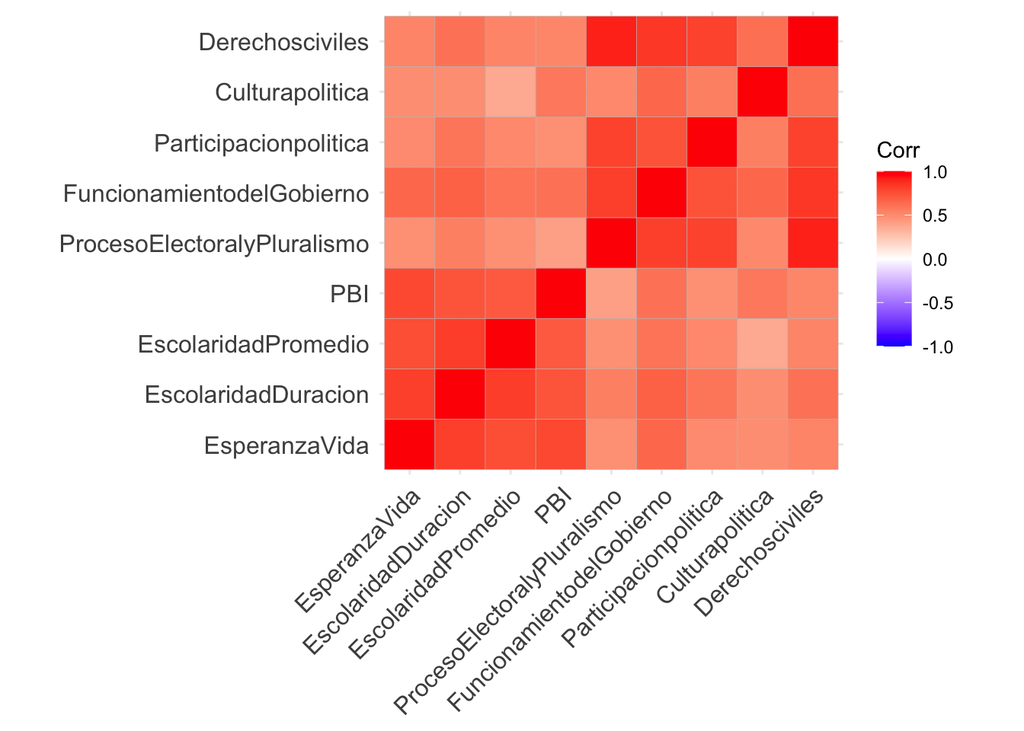

Figure 2.1: Matriz de Correlaciones

```r
library(ggcorrplot)

ggcorrplot(corMatrix)
```

Si puedes ver bloques correlacionados en la Figura 2.1, hay esperanza de un buen analisis factorial.

4. Verificar si los datos permiten factorizar:

```r
library(psych)
psych::KMO(corMatrix)
```

```
## Kaiser-Meyer-Olkin factor adequacy
## Call: psych::KMO(r = corMatrix)
## Overall MSA =  0.9
## MSA for each item =
##               EsperanzaVida         EscolaridadDuracion
##                        0.90                        0.91
##         EscolaridadPromedio                         PBI
##                        0.90                        0.89
## ProcesoElectoralyPluralismo   FuncionamientodelGobierno
##                        0.83                        0.95
##       Participacionpolitica             Culturapolitica
##                        0.96                        0.88
##             Derechosciviles
##                        0.86
```

5. Verificar si la matriz de correlaciones es adecuada

Aqui hay dos pruebas:

- Hnula: La matriz de correlacion es una [matriz identidad](https://en.wikipedia.org/wiki/Identity_matrix)

```r
cortest.bartlett(corMatrix,n=nrow(theData))$p.value>0.05
```

```
## [1] FALSE
```

- Hnula: La matriz de correlacion es una [matriz singular](http://mathworld.wolfram.com/SingularMatrix.html).

```r
library(matrixcalc)

is.singular.matrix(corMatrix)
```

```
## [1] FALSE
```

6. Determinar en cuantos factores o variables latentes podríamos redimensionar la data: En este caso, la función *fa.parallel* nos dará la sugerencia:

```r
fa.parallel(theData, fa = 'fa',correct = T,plot = F)
```

```
## Parallel analysis suggests that the number of factors =  2  and the number of components =  NA
```

Se sugieren 2, lo esperado, sigamos.

7. Redimensionar a número menor de factores
- Resultado inicial:

```r
library(GPArotation)
resfa <- fa(theData,
            nfactors = 2,
            cor = 'mixed',
            rotate = "varimax",
            fm="minres")
print(resfa$loadings)
```

```
##
## Loadings:
##                             MR1   MR2
## EsperanzaVida               0.292 0.858
## EscolaridadDuracion         0.385 0.817
## EscolaridadPromedio         0.293 0.794
## PBI                         0.288 0.805
## ProcesoElectoralyPluralismo 0.907 0.232
## FuncionamientodelGobierno   0.767 0.485
## Participacionpolitica       0.779 0.333
## Culturapolitica             0.525 0.396
## Derechosciviles             0.911 0.319
##
##                  MR1   MR2
## SS loadings    3.525 3.342
## Proportion Var 0.392 0.371
## Cumulative Var 0.392 0.763
```

- Resultado mejorado (solo apropiado si hay más de un factor):

```r
print(resfa$loadings,cutoff = 0.5)
```

```
##
## Loadings:
##                             MR1   MR2
## EsperanzaVida                     0.858
## EscolaridadDuracion               0.817
## EscolaridadPromedio               0.794
## PBI                               0.805
## ProcesoElectoralyPluralismo 0.907
## FuncionamientodelGobierno   0.767
## Participacionpolitica       0.779
## Culturapolitica             0.525
## Derechosciviles             0.911
##
##                  MR1   MR2
## SS loadings    3.525 3.342
## Proportion Var 0.392 0.371
## Cumulative Var 0.392 0.763
```

Cuando logramos que cada variable se vaya a un factor, tenemos una *estructura simple*.

- Resultado visual: El resultado lo podemos ver de manera gráfica en la Figura 2.2.

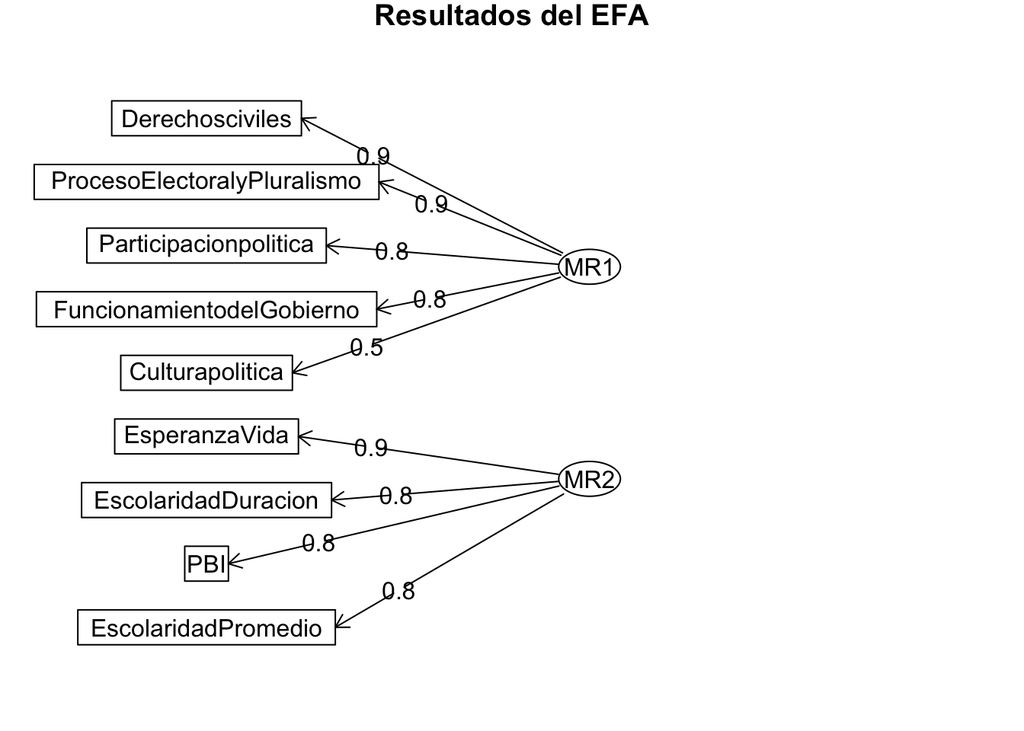

Figure 2.2: Variables organizadas en Factores

```r
fa.diagram(resfa,main = "Resultados del EFA")
```

8. Evaluando Resultado obtenido:
- ¿Qué variables aportaron mas a los factores?

```r
sort(resfa$communality)
```

```
##             Culturapolitica         EscolaridadPromedio
##                   0.4316871                   0.7166172
##       Participacionpolitica                         PBI
##                   0.7171086                   0.7315372
##         EscolaridadDuracion               EsperanzaVida
##                   0.8152815                   0.8218358
##   FuncionamientodelGobierno ProcesoElectoralyPluralismo
##                   0.8242581                   0.8769256
##             Derechosciviles
##                   0.9313582
```

- ¿Qué variables contribuyen a más de un factor?

```r
sort(resfa$complexity)
```

```
## ProcesoElectoralyPluralismo               EsperanzaVida
##                    1.129684                    1.227611
##             Derechosciviles                         PBI
##                    1.241301                    1.251340
##         EscolaridadPromedio       Participacionpolitica
##                    1.267392                    1.354502
##         EscolaridadDuracion   FuncionamientodelGobierno
##                    1.424026                    1.690069
##             Culturapolitica
##                    1.859382
```

9. Valores proyectados: Podemos calcular dos *indices* que resuman los dos factores encontrados.

```r
library(magrittr)
as.data.frame(resfa$scores)%>%head()
```

```
##          MR1        MR2
## 1 -1.7797155 -0.8641013
## 2  0.3153599  0.2795472
## 3  1.0173337  1.1873533
## 4 -0.7565796 -0.6723471
## 5 -2.0055735  1.6069436
## 6 -0.8703269  0.4062909
```

Les daremos por nombre ‘demos_efa’ y ‘desahu_efa’ a esas dos columnas. Dado que tenemos el indice de democracia en la data original, comparémoslo con el recién calculado, via el *scatterplot* de la Figura 2.3.

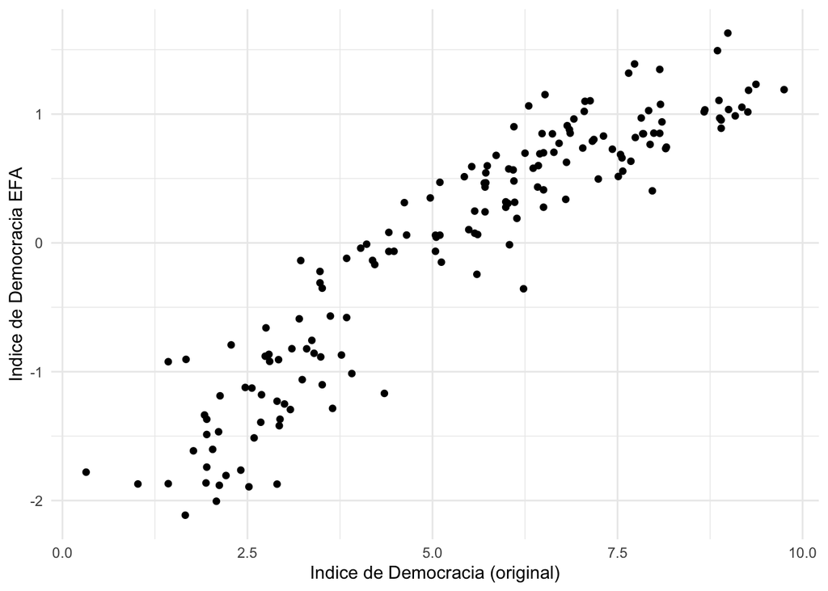

Figure 2.3: Comparando Indice de Democracia con el Score obtenido en EFA

```r
idhdemo$demos_efa=resfa$scores[,1]
idhdemo$desahu_efa=resfa$scores[,2]

ggplot(data=idhdemo,aes(x=Puntuacion,y=demos_efa)) + geom_point() + theme_minimal() + labs(x="Indice de Democracia (original)", y="Indice de Democracia EFA")
```

Nota que los rangos de los valores en la Figura 2.3 no son los mismos. La Figura 2.4 muestra tales cambios.

```r
library(BBmisc)
```

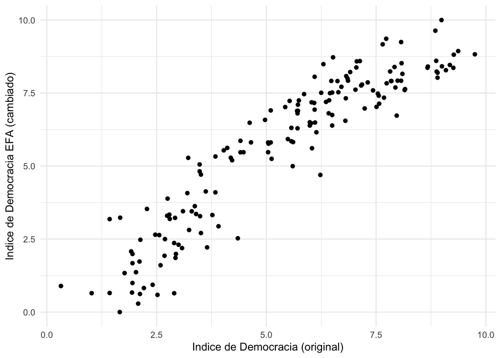

Figure 2.4: Comparación Indice de Democracia con Score EFA con rangos coincidentes

```r
efa_scores_ok=normalize(resfa$scores,
                       method = "range",
                       margin=2, # by column
                       range = c(0, 10))

idhdemo$demos_efa_ok=efa_scores_ok[,1]
idhdemo$desahu_efa_ok=efa_scores_ok[,2]

ggplot(data=idhdemo,aes(x=Puntuacion,y=demos_efa_ok)) + geom_point() + theme_minimal() + labs(x="Indice de Democracia (original)", y="Indice de Democracia EFA (cambiado)")
```

# 3 Análisis Factorial Confirmatorio

El análisis factorial confirmatorio (CFA) lo usamos cuando ya tenemos una teoría y queremos confirmar que los datos pueden reflejar los conceptos o variables latentes asumidas Orcan (2018).

```r
modelCFA <- ' democracia  =~ ProcesoElectoralyPluralismo + FuncionamientodelGobierno + Participacionpolitica + Culturapolitica + Derechosciviles

desaHumano=~EsperanzaVida+EscolaridadDuracion+EscolaridadPromedio+PBI'
```

Ahora vemos qué arroja el modelo:

```r
# normalizar las variables:
theDataNorm=scale(theData)

library(lavaan)
cfa_fit <- cfa(modelCFA, data=theDataNorm,
           std.lv=TRUE,
           missing="fiml")
summary(cfa_fit)
```

```
## lavaan 0.6-12 ended normally after 30 iterations
##
##   Estimator                                         ML
##   Optimization method                           NLMINB
##   Number of model parameters                        28
##
##   Number of observations                           162
##   Number of missing patterns                         1
##
## Model Test User Model:
##
##   Test statistic                               120.470
##   Degrees of freedom                                26
##   P-value (Chi-square)                           0.000
##
## Parameter Estimates:
##
##   Standard errors                             Standard
##   Information                                 Observed
##   Observed information based on                Hessian
##
## Latent Variables:
##                    Estimate  Std.Err  z-value  P(>|z|)
##   democracia =~
##     PrcsElctrlyPlr    0.929    0.059   15.654    0.000
##     FuncnmntdlGbrn    0.881    0.062   14.271    0.000
##     Participcnpltc    0.839    0.064   13.176    0.000
##     Culturapolitic    0.635    0.071    8.933    0.000
##     Derechoscivils    0.962    0.058   16.675    0.000
##   desaHumano =~
##     EsperanzaVida     0.890    0.062   14.342    0.000
##     EscolariddDrcn    0.915    0.061   15.045    0.000
##     EscolariddPrmd    0.867    0.063   13.761    0.000
##     PBI               0.825    0.065   12.680    0.000
##
## Covariances:
##                    Estimate  Std.Err  z-value  P(>|z|)
##   democracia ~~
##     desaHumano        0.671    0.048   13.987    0.000
##
```

[output cut: 12 more lines]

```
##     desaHumano        0.000
##
## Variances:
##                    Estimate  Std.Err  z-value  P(>|z|)
##    .PrcsElctrlyPlr    0.131    0.019    6.759    0.000
##    .FuncnmntdlGbrn    0.217    0.029    7.551    0.000
##    .Participcnpltc    0.290    0.036    8.072    0.000
##    .Culturapolitic    0.591    0.068    8.744    0.000
##    .Derechoscivils    0.068    0.016    4.336    0.000
##    .EsperanzaVida     0.202    0.032    6.383    0.000
##    .EscolariddDrcn    0.156    0.028    5.526    0.000
##    .EscolariddPrmd    0.243    0.034    7.088    0.000
##    .PBI               0.313    0.042    7.494    0.000
##     democracia        1.000
##     desaHumano        1.000
```

Averigüemos qué tan bien salió el modelo:

```r
allParamCFA=parameterEstimates(cfa_fit,standardized = T)
allFitCFA=as.list(fitMeasures(cfa_fit))
```

- El ChiSquare es NO significativo? (p_value debe ser mayor a 0.05 para que sea bueno)

```r
allFitCFA[c("chisq", "df", "pvalue")] # pvalue>0.05
```

```
## $chisq
## [1] 120.4701
##
## $df
## [1] 26
##
## $pvalue
## [1] 4.096723e-14
```

- El Índice Tucker Lewis es mayor a 0.9?

```r
allFitCFA$tli
```

```
## [1] 0.9098333
```

- La Raíz del error cuadrático medio de aproximación es menor a 0.05?

```r
allFitCFA[c('rmsea.ci.lower','rmsea' ,'rmsea.ci.upper')]
```

```
## $rmsea.ci.lower
## [1] 0.1233283
##
## $rmsea
## [1] 0.1497624
##
## $rmsea.ci.upper
## [1] 0.1773093
```

Ya sabemos que las latentes no cumplen a cabalidad los requisitos, pero aún así calculamos las puntuaciones obtenidas por esta vía.

```r
scorescfa=normalize(lavPredict(cfa_fit),
                    method = "range",
                    margin=2, # by column
                    range = c(0, 10))

idhdemo$demos_cfa_ok=scorescfa[,1]
idhdemo$desahu_cfa_ok=scorescfa[,2]
```

Veamos que tanto se parece el score obtenido via CFA con la puntuación original en la Figura 3.1.

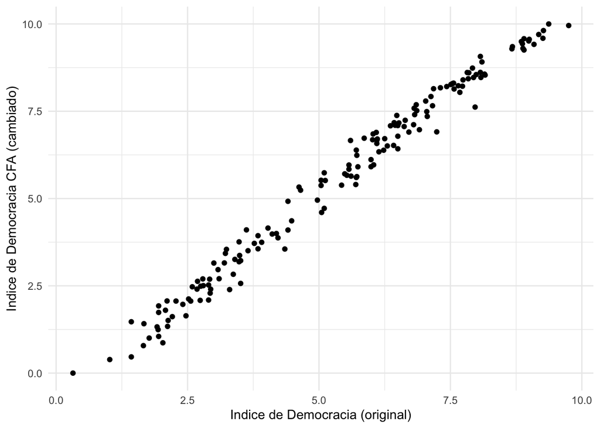

Figure 3.1: Comparación Indice de Democracia con Score CFA con puntuación original

```r
ggplot(data=idhdemo,aes(x=Puntuacion,y=demos_cfa_ok)) + geom_point() + theme_minimal() + labs(x="Indice de Democracia (original)", y="Indice de Democracia CFA (cambiado)")
```

Podemos ver los resultados del CFA en la Figura 3.2.

```r
library(lavaanPlot)
lavaanPlot(model = cfa_fit, node_options = list(shape = "box", fontname = "Helvetica"), edge_options = list(color = "grey"), coefs = T)
```

[interactive chart not shown]

Figure 3.2: Representación del CFA - Democracia y IDH

Podríamos hacer una regresión donde una de estas latentes es la dependiente y la otra la independiente. El siguiente paso en esta línea sería usar un modelo de **Ecuaciones Estructurales**. Primero usemos la regresión convencional, encontrando estos resultados:

```r
hipotesis=formula(demos_cfa_ok~desahu_cfa_ok)
reg1=lm(hipotesis, data=idhdemo)
summary(reg1)
```

```
##
## Call:
## lm(formula = hipotesis, data = idhdemo)
##
## Residuals:
##     Min      1Q  Median      3Q     Max
## -5.1469 -1.1895  0.5652  1.2064  3.4735
##
## Coefficients:
##               Estimate Std. Error t value Pr(>|t|)
## (Intercept)    1.57634    0.34956    4.51 1.25e-05 ***
## desahu_cfa_ok  0.76985    0.06168   12.48  < 2e-16 ***
## ---
## Signif. codes:  0 '***' 0.001 '**' 0.01 '*' 0.05 '.' 0.1 ' ' 1
##
## Residual standard error: 1.927 on 160 degrees of freedom
## Multiple R-squared:  0.4933, Adjusted R-squared:  0.4901
## F-statistic: 155.8 on 1 and 160 DF,  p-value: < 2.2e-16
```

Ahora, usando variables latentes en una Ecuación Estructural.

```r
modelSEM <- ' democracia  =~ ProcesoElectoralyPluralismo + FuncionamientodelGobierno + Participacionpolitica + Culturapolitica + Derechosciviles

desaHumano=~EsperanzaVida+EscolaridadDuracion+EscolaridadPromedio+PBI

democracia~desaHumano'
```

Los resultados son:

```r
sem_fit <- sem(modelSEM,
              data=theDataNorm)
summary(sem_fit)
```

```
## lavaan 0.6-12 ended normally after 33 iterations
##
##   Estimator                                         ML
##   Optimization method                           NLMINB
##   Number of model parameters                        19
##
##   Number of observations                           162
##
## Model Test User Model:
##
##   Test statistic                               120.470
##   Degrees of freedom                                26
##   P-value (Chi-square)                           0.000
##
## Parameter Estimates:
##
##   Standard errors                             Standard
##   Information                                 Expected
##   Information saturated (h1) model          Structured
##
## Latent Variables:
##                    Estimate  Std.Err  z-value  P(>|z|)
##   democracia =~
##     PrcsElctrlyPlr    1.000
##     FuncnmntdlGbrn    0.949    0.050   18.861    0.000
##     Participcnpltc    0.903    0.055   16.523    0.000
##     Culturapolitic    0.683    0.070    9.805    0.000
##     Derechoscivils    1.036    0.041   25.199    0.000
##   desaHumano =~
##     EsperanzaVida     1.000
##     EscolariddDrcn    1.028    0.058   17.736    0.000
##     EscolariddPrmd    0.974    0.062   15.807    0.000
##     PBI               0.927    0.065   14.304    0.000
##
## Regressions:
##                    Estimate  Std.Err  z-value  P(>|z|)
##   democracia ~
##     desaHumano        0.700    0.074    9.453    0.000
##
## Variances:
##                    Estimate  Std.Err  z-value  P(>|z|)
##    .PrcsElctrlyPlr    0.131    0.020    6.531    0.000
##    .FuncnmntdlGbrn    0.217    0.028    7.747    0.000
##    .Participcnpltc    0.290    0.036    8.173    0.000
##    .Culturapolitic    0.591    0.067    8.775    0.000
##    .Derechoscivils    0.068    0.016    4.291    0.000
##    .EsperanzaVida     0.202    0.031    6.562    0.000
##    .EscolariddDrcn    0.156    0.028    5.688    0.000
##    .EscolariddPrmd    0.243    0.034    7.097    0.000
##    .PBI               0.313    0.041    7.683    0.000
##    .democracia        0.474    0.065    7.316    0.000
##     desaHumano        0.792    0.110    7.187    0.000
```

El resultado podemos verlo de manera gráfica en la Figura 3.3.

```r
lavaanPlot(model = sem_fit,
           node_options = list(shape = "box",
                               fontname = "Helvetica"),
           edge_options = list(color = "grey"), coefs = T,stand = T)
```

[interactive chart not shown]

Figure 3.3: SEM con Democracia como dependiente e IDH como independiente

El mismo resultado podemos verlo de manera gráfica usando otra la biblioteca *semPlot* en la Figura 3.4.

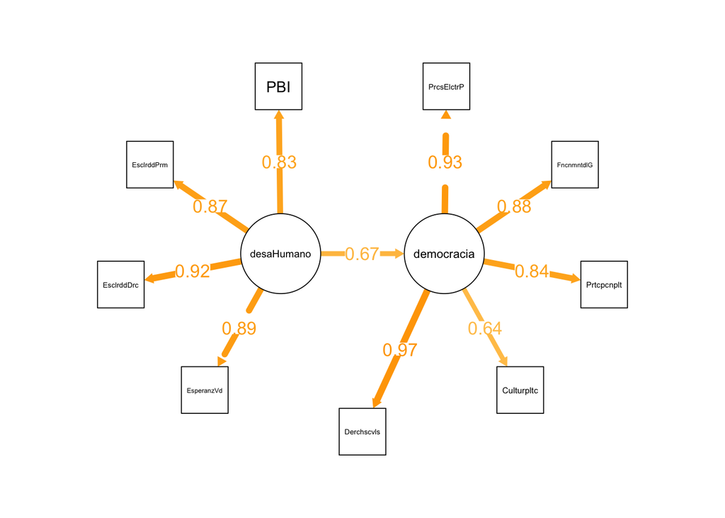

Figure 3.4: SEM alternativo con Democracia como dependiente e IDH como independiente

```r
library(semPlot)
semPaths(sem_fit, residuals=F,
         sizeMan=7,sizeLat=12,
         what = "std",
         nCharNodes=10,
         posCol=c("skyblue4", "red"),
         edge.color="orange",
         edge.label.cex=1.2,layout="circle2")
```

# Referencias

Costa, Vera, and Rui Sarmento. n.d. “Confirmatory Factor Analysis,” 39.

Orcan, Fatih. 2018. “Exploratory and Confirmatory Factor Analysis: Which One to Use First?” *Eğitimde Ve Psikolojide Ölçme Ve Değerlendirme Dergisi*, December, 414–21. https://doi.org/10.21031/epod.394323.

Watkins, Marley W. 2018. “Exploratory Factor Analysis: A Guide to Best Practice.” *Journal of Black Psychology* 44 (3): 219–46. https://doi.org/10.1177/0095798418771807.

[^1]: Sí A y B son conjuntos, A−B serán los elementos que están en A pero que NO están en B, por ejemplo si A={1,2,3} y B={3,5}, entonces A−B={1,2}.